# Lab 5

Nicholas Heger

11/5/2020

## Questions

1. Are there some days of the week where more accidents happen than the others (see FARS manual, use variable DAY_WEEK)?

```r
acc1 <- acc %>%
  group_by(DAY_WEEK)
count(acc1)
```

```
## # A tibble: 7 x 2
## # Groups:   DAY_WEEK [7]
##   DAY_WEEK     n
##      <int> <int>
## 1        1  5360
## 2        2  4374
## 3        3  4347
## 4        4  4314
## 5        5  4621
## 6        6  5358
## 7        7  5873
```

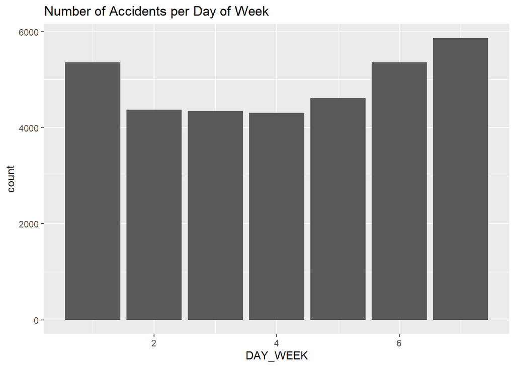

```r
ggplot(acc, aes(x=DAY_WEEK)) + geom_bar() + ggtitle('Number of Accidents per Day of Week')
```

Yes, accidents happen most often on Saturdays. I confirmed that 7 corresponds to Saturday by checking the user’s manual for the data.

2. Create a data frame containing the persons who are fatally hurt in the accidents (look up variable INJ_SEV)

```r
fatal <- per %>%
  filter(INJ_SEV == 4)
head(fatal)
```

```
##   STATE ST_CASE VE_FORMS VEH_NO PER_NO STR_VEH COUNTY DAY MONTH HOUR MINUTE
## 1     1   10001        1      1      1       0     73  19     2   23     35
## 2     1   10002        1      1      1       0     89  14     2   14     59
## 3     1   10003        3      2      1       0    101  31     1   20     31
## 4     1   10004        1      1      1       0     73   1     1   16     55
## 5     1   10005        1      1      1       0     13   1     1   20      0
## 6     1   10006        2      1      1       0     49   6     1   18     40
##   RUR_URB FUNC_SYS HARM_EV MAN_COLL SCH_BUS MAKE MAK_MOD BODY_TYP MOD_YEAR
## 1       2        1      38        0       0   20   20421       15     2004
## 2       2        1       1        0       0   37   37402       14     2005
## 3       2        1      12        1       0    2    2404       14     2003
## 4       2        4      30        0       0   30   30046        4     2014
## 5       1        1      35        0       0   12   12471       34     2010
## 6       1        1      34        0       0   49   49032        4     1997
##   TOW_VEH SPEC_USE EMER_USE ROLLOVER IMPACT1 FIRE_EXP AGE SEX PER_TYP INJ_SEV
```

[output cut: 41 more lines]

3. Create a data frame containing the most dangerous vehicle make in each state. The number of persons fatally hit in the vehicle make is used to assess the (non-)safety of a make. Make sure to handle the missing values appropriately. (look up variable MAKE)

```r
FatalMakeState <- fatal %>%
  group_by(STATE, MAKE)
count1 <- count(FatalMakeState)
badMakes <- count1 %>%
  arrange(STATE, desc(n))
badMakes <- badMakes[complete.cases(badMakes),]
bad <- badMakes %>%
  group_by(STATE) %>%
  slice(1)
bad
```

```
## # A tibble: 51 x 3
## # Groups:   STATE [51]
##    STATE  MAKE     n
##    <int> <int> <int>
##  1     1    12   138
##  2     2    12     9
##  3     4    20    88
##  4     5    20    88
##  5     6    49   351
##  6     8    12    63
##  7     9    37    28
##  8    10    37    12
##  9    11    37     5
## 10    12    12   237
## # ... with 41 more rows
```

4. Create a map, and label each state with the most dangerous vehicle. Discuss the definition of the most dangerous vehicle, and what you find from the map. (Hint: Read the description for the STATE and COUNTY columns in the FARS manual. The state & county codes are Geographic Locator Codes (GLCs) from the General Services Administration’s (GSA) publication. Use readxl::read_xlsx to read in the GLCs.)

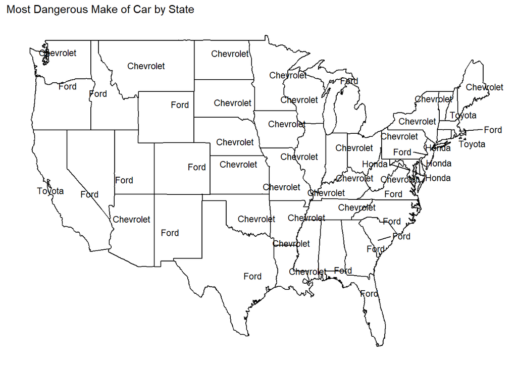

```r
stateCodes$State <- tolower(stateCodes$State)
badMakesWithCodes <- bad %>%
  left_join(makeCodes, by=c('MAKE'='Codes')) %>%
  left_join(stateCodes, by=c('STATE'='Codes'))
badMakesWithCodesMap <- badMakesWithCodes %>%
  left_join(states, by=c('State'='region'))
states %>%
  group_by(region) %>%
  summarise(long=mean(long), lat=mean(lat), .groups='keep') %>%
  left_join(badMakesWithCodes, by=c('region'='State')) -> stateLabels

ggplot(badMakesWithCodesMap, aes(x=long, y=lat)) +
  geom_path(aes(group=group)) +
  geom_text_repel(data=stateLabels, aes(label=Make), size=3) +
  ggtitle('Most Dangerous Make of Car by State') +
  theme_map()
```

The most dangerous makes being shown in this graph are defined by the make of car that the most fatal injuries have occurred in. Because this is not a percentage, the makes shown here are more likely to be more popular makes of cars since more people own them. We can find from this map that Chevrolet seems to be a dangerous (and/or popular) make of car in most of the united states, especially the Midwest.

5. Join the accident and person table (work out which variable(s) to use)

```r
acc_per <- inner_join(acc, per, by=c("STATE", "ST_CASE", "VE_FORMS", "COUNTY", "DAY", "MONTH", "HOUR", "MINUTE", "RUR_URB", "FUNC_SYS", "HARM_EV", "MAN_COLL", "SCH_BUS"))
str(acc_per)
```

```
## 'data.frame':    84921 obs. of  107 variables:
##  $ STATE     : int  1 1 1 1 1 1 1 1 1 1 ...
##  $ ST_CASE   : int  10001 10002 10003 10003 10003 10004 10005 10005 10006 10006 ...
##  $ VE_TOTAL  : int  1 1 3 3 3 1 1 1 2 2 ...
##  $ VE_FORMS  : int  1 1 3 3 3 1 1 1 2 2 ...
##  $ PVH_INVL  : int  0 0 0 0 0 0 0 0 0 0 ...
##  $ PEDS      : int  0 0 0 0 0 0 0 0 0 0 ...
##  $ PERNOTMVIT: int  0 0 0 0 0 0 0 0 0 0 ...
##  $ PERMVIT   : int  1 1 3 3 3 1 2 2 4 4 ...
##  $ PERSONS   : int  1 1 3 3 3 1 2 2 4 4 ...
##  $ COUNTY    : int  73 89 101 101 101 73 13 13 49 49 ...
##  $ CITY      : int  330 1730 2130 2130 2130 350 0 0 0 0 ...
##  $ DAY       : int  19 14 31 31 31 1 1 1 6 6 ...
##  $ MONTH     : int  2 2 1 1 1 1 1 1 1 1 ...
##  $ YEAR      : int  2017 2017 2017 2017 2017 2017 2017 2017 2017 2017 ...
```

[output cut: 86 more lines]

6. Tally the number of accidents by day of the week (DAY_WEEK), hour of the day (HOUR) and gender (SEX). Visualize the results.

```r
accidentsByDayHourGender <- acc_per %>%
  group_by(DAY_WEEK, HOUR, SEX) %>%
  summarize(Number_of_Accidents = sum(DAY_WEEK, HOUR, SEX)) %>%
  filter((SEX == 1 | SEX == 2) & HOUR != 99) %>%
  mutate(SEX = ifelse(SEX == 1, 'Male', 'Female'))
accidentsByDayHourGender <- left_join(accidentsByDayHourGender, dayCodes, by=c('DAY_WEEK' = 'Code'))
accidentsByDayHourGender
```

```
## # A tibble: 336 x 5
## # Groups:   DAY_WEEK, HOUR [168]
##    DAY_WEEK  HOUR SEX    Number_of_Accidents Day_Week
##       <dbl> <int> <chr>                <int> <chr>
##  1        1     0 Male                   976 Sunday
##  2        1     0 Female                 663 Sunday
##  3        1     1 Male                  1446 Sunday
##  4        1     1 Female                 800 Sunday
##  5        1     2 Male                  2140 Sunday
##  6        1     2 Female                1190 Sunday
##  7        1     3 Male                  1880 Sunday
##  8        1     3 Female                 888 Sunday
##  9        1     4 Male                  1872 Sunday
## 10        1     4 Female                 553 Sunday
## # ... with 326 more rows
```

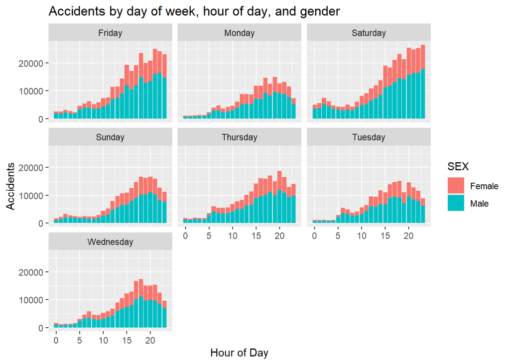

```r
accidentsByDayHourGender %>% ggplot(aes(x=HOUR, y = Number_of_Accidents, fill=SEX)) + geom_bar(stat="identity") + facet_wrap(~Day_Week) + ylab('Accidents') + xlab('Hour of Day') + ggtitle('Accidents by day of week, hour of day, and gender')
```

According to the above graph, more males are involved in accidents than females, and Friday and Saturday seem to be the days with the most accidents, mostly in the evenings and nights.

7. Now plot a choropleth map of the number of deaths on a county level.

```r
countiesTemp <- counties
accidentsByCounty <- acc_per %>%
  group_by(STATE, COUNTY, INJ_SEV) %>%
  filter(INJ_SEV == 4) %>%
  summarize(total = sum(INJ_SEV))
```

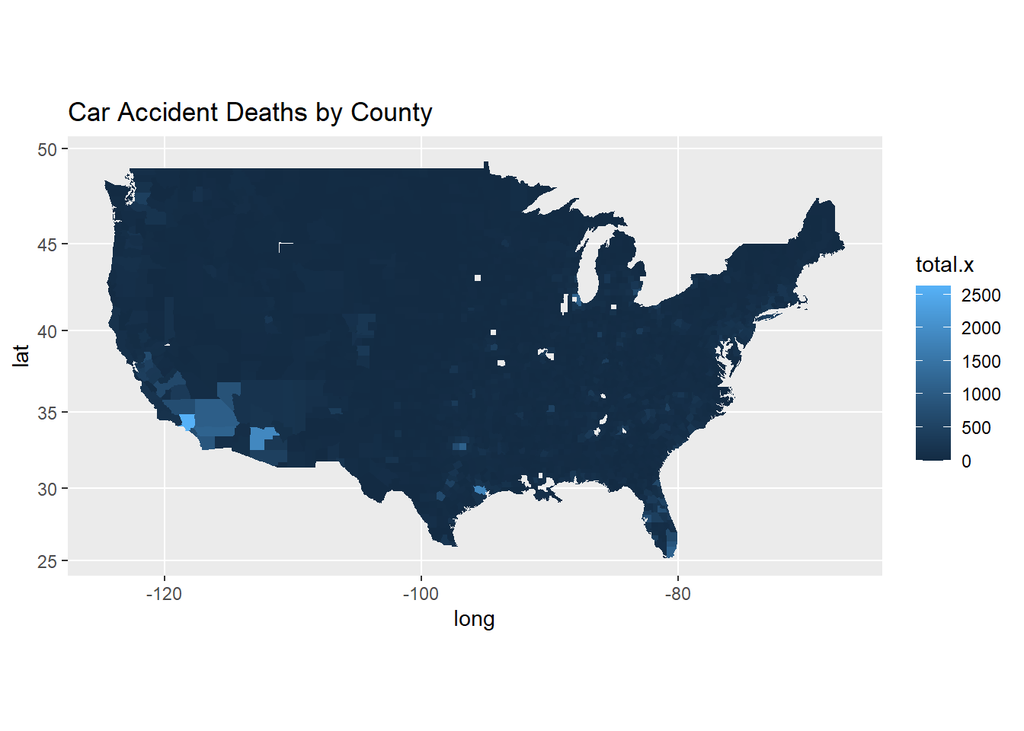

```r
countyCodes <- unitedStates %>%
  select('County Name', 'County Code', 'State Name', 'State Code') %>%
  mutate('County Name' = tolower(unitedStates$`County Name`)) %>%
  mutate('State Name' = tolower(unitedStates$`State Name`))
countiesTemp <- right_join(countiesTemp, countyCodes, by=c("region" = "State Name", "subregion" = "County Name"))
countiesTemp <- countiesTemp %>%
  mutate("County Code" = as.numeric(countiesTemp$`County Code`)) %>%
  mutate("State Code" = as.numeric(countiesTemp$`State Code`)) %>%
  left_join(accidentsByCounty, by=c("County Code" = "COUNTY", "State Code" = "STATE")) %>%
  mutate(total.x = ifelse(is.na(total), 0, total))
ggplot(countiesTemp, aes(x=long, y=lat, fill=total.x)) + geom_polygon(aes(group = group, fill=total.x)) + coord_map() + ggtitle('Car Accident Deaths by County')
```

The above graph shows that the counties with the most car accident deaths are in Southern California, with a few other higher car accident death counties in Texas and Florida.

8. Is summer or winter more dangerous? Does this depend on states? Explore and explain.

Summer

```r
summerFatalities <- fatal %>%
  filter(MONTH >= 6 & MONTH <=9)
summerFatalitiesByState <- summerFatalities %>%
  select(ST_CASE, STATE, PER_NO) %>%
  group_by(STATE) %>%
  summarise(Fatalities=sum(PER_NO))
summerFatalitiesByState
```

```
## # A tibble: 51 x 2
##    STATE Fatalities
##    <int>      <int>
##  1     1        386
##  2     2         37
##  3     4        408
##  4     5        242
##  5     6       1528
##  6     8        365
##  7     9        125
##  8    10         59
##  9    11         14
## 10    12       1116
## # ... with 41 more rows
```

```r
mean(summerFatalitiesByState$Fatalities)
```

```
## [1] 326.2353
```

Winter

```r
winterFatalities <- fatal %>%
  filter(MONTH <= 3 | MONTH == 12)
winterFatalitiesByState <- winterFatalities %>%
  select(ST_CASE, STATE, PER_NO) %>%
  group_by(STATE) %>%
  summarise(Fatalities=sum(PER_NO))
winterFatalitiesByState
```

```
## # A tibble: 51 x 2
##    STATE Fatalities
##    <int>      <int>
##  1     1        373
##  2     2         32
##  3     4        399
##  4     5        182
##  5     6       1394
##  6     8        219
##  7     9         94
##  8    10         39
##  9    11         14
## 10    12       1352
## # ... with 41 more rows
```

```r
mean(winterFatalitiesByState$Fatalities)
```

```
## [1] 280.7255
```